# Introduction

In this project, you will build a neural network of your own design to evaluate the CIFAR-10 dataset. Our target accuracy is 70%, but any accuracy over 50% is a great start. Some of the benchmark results on CIFAR-10 include:

78.9% Accuracy | [Deep Belief Networks; Krizhevsky, 2010](https://www.cs.toronto.edu/~kriz/conv-cifar10-aug2010.pdf)

90.6% Accuracy | [Maxout Networks; Goodfellow et al., 2013](https://arxiv.org/pdf/1302.4389.pdf)

96.0% Accuracy | [Wide Residual Networks; Zagoruyko et al., 2016](https://arxiv.org/pdf/1605.07146.pdf)

99.0% Accuracy | [GPipe; Huang et al., 2018](https://arxiv.org/pdf/1811.06965.pdf)

98.5% Accuracy | [Rethinking Recurrent Neural Networks and other Improvements for ImageClassification; Nguyen et al., 2020](https://arxiv.org/pdf/2007.15161.pdf)

Research with this dataset is ongoing. Notably, many of these networks are quite large and quite expensive to train.

## Imports

```python
## This cell contains the essential imports you will need – DO NOT CHANGE THE CONTENTS! ##
import torch
import torch.nn as nn
import torch.nn.functional as F
import torch.optim as optim
import torchvision
from torchvision.datasets import ImageFolder
from torchvision import datasets, transforms, models
import matplotlib.pyplot as plt
import numpy as np
import seaborn as sns
import tarfile
import os
from torch.utils.data import random_split
from torchvision.utils import make_grid
import wandb
```

```python
print(torch.__version__)
```

```
1.7.0
```

```python
%matplotlib inline
%config InlineBackend.figure_format = 'retina'
```

## Load the Dataset

Specify your transforms as a list first. The transforms module is already loaded as `transforms`.

CIFAR-10 is fortunately included in the torchvision module. Then, you can create your dataset using the `CIFAR10` object from `torchvision.datasets` ([the documentation is available here](https://pytorch.org/docs/stable/torchvision/datasets.html#cifar)). Make sure to specify `download=True`!

Once your dataset is created, you'll also need to define a `DataLoader` from the `torch.utils.data` module for both the train and the test set.

```python
data_dir = './data/CIFAR-10-images'
print(os.listdir(data_dir))
classes= os.listdir(os.path.join(data_dir,'train'))
print(classes)
```

```
['.git', 'README.md', 'test', 'train']
['airplane', 'automobile', 'bird', 'cat', 'deer', 'dog', 'frog', 'horse', 'ship', 'truck']
```

```python
train_dict = {}
for i in classes:
    train_dict[i] = os.listdir(os.path.join(data_dir,'train',i))
    print('No of training example for {}:'.format(i),len(train_dict[i]))
```

```
No of training example for airplane: 5000
No of training example for automobile: 5000
No of training example for bird: 5000
No of training example for cat: 5000
No of training example for deer: 5000
No of training example for dog: 5000
No of training example for frog: 5000
No of training example for horse: 5000
No of training example for ship: 5000
No of training example for truck: 5000
```

```python
test_dict = {}
for i in classes:
    test_dict[i] = os.listdir(os.path.join(data_dir,'test',i))
    print('No of testing example for {}:'.format(i),len(test_dict[i]))
```

```
No of testing example for airplane: 1000
No of testing example for automobile: 1000
No of testing example for bird: 1000
No of testing example for cat: 1000
No of testing example for deer: 1000
No of testing example for dog: 1000
No of testing example for frog: 1000
No of testing example for horse: 1000
No of testing example for ship: 1000
No of testing example for truck: 1000
```

```python
random_seed=42
torch.manual_seed(random_seed);
```

```python
# Define transforms
train_transforms = transforms.Compose([transforms.RandomRotation(30),
                                       transforms.RandomResizedCrop(224),
                                       transforms.RandomHorizontalFlip(),
                                       transforms.ToTensor(),
                                       transforms.Normalize([0.485, 0.456, 0.406],
                                                            [0.229, 0.224, 0.225])])

test_transforms = transforms.Compose([transforms.Resize(255),
                                      transforms.CenterCrop(224),
                                      transforms.ToTensor(),
                                      transforms.Normalize([0.485, 0.456, 0.406],
                                                           [0.229, 0.224, 0.225])])
# Create training set and define training dataloader
# train and val dataset object made from ImageFolder class(WITHOUT TRANSFORM)

trainset = ImageFolder(data_dir+'/train', transform=transforms.ToTensor())
val_size = 5000
train_size = len(trainset) - val_size
trainset, valset = random_split(trainset,[train_size, val_size],generator=torch.manual_seed(random_seed))
len(trainset), len(valset)

# train and val dataset object made from ImageFolder class(WITh TRANSFORM)

trainset_transforms = ImageFolder(data_dir+'/train', transform=train_transforms)
train_size = len(trainset_transforms) - val_size
trainset_transforms, valset_transforms = random_split(trainset_transforms,[train_size, val_size],generator=torch.manual_seed(random_seed))
len(trainset_transforms), len(valset_transforms)
```

```
(45000, 5000)
```

```python
# Dataloaders for the train and val sets for both with and without transforms
trainloader = torch.utils.data.DataLoader(trainset, batch_size=64, shuffle=True)
valloader = torch.utils.data.DataLoader(valset, batch_size=64, shuffle=True)
trainloader_transforms = torch.utils.data.DataLoader(trainset_transforms, batch_size=64, shuffle=True)
valloader_transforms = torch.utils.data.DataLoader(valset_transforms, batch_size=64, shuffle=True)
```

```python
# Create test set and define test dataloader

testset = ImageFolder(data_dir+'/test', transform=transforms.ToTensor())
testset_transforms = ImageFolder(data_dir+'/test', transform=test_transforms)
testloader = torch.utils.data.DataLoader(testset, batch_size=64)
testloader_transforms = torch.utils.data.DataLoader(testset_transforms, batch_size=64, shuffle=False)
```

## Explore the Dataset

Using matplotlib, numpy, and torch, explore the dimensions of your data.

You can view images using the `show5` function defined below – it takes a data loader as an argument. Remember that normalized images will look really weird to you! You may want to try changing your transforms to view images. Typically using no transforms other than `toTensor()` works well for viewing – but not as well for training your network. If `show5` doesn't work, go back and check your code for creating your data loaders and your training/test sets.

```python
def show5(img_loader):
    dataiter = iter(img_loader)

    batch = next(dataiter)
    labels = batch[1][0:5]
    images = batch[0][0:5]
    for i in range(5):
        print(classes[labels[i]])

        image = images[i].numpy()
        print(image.shape)
        plt.imshow(image.T)
        plt.show()
```

```
dog
(3, 32, 32)
```

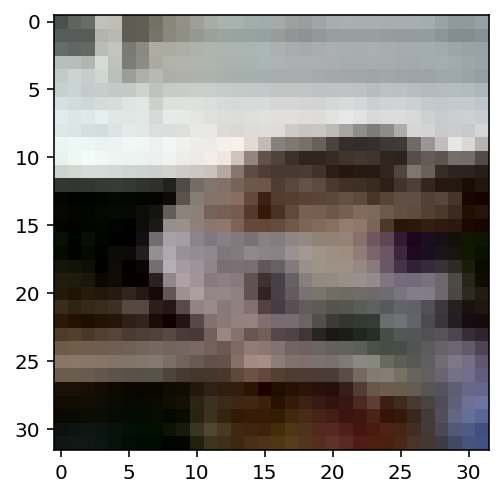

```
frog
(3, 32, 32)
```

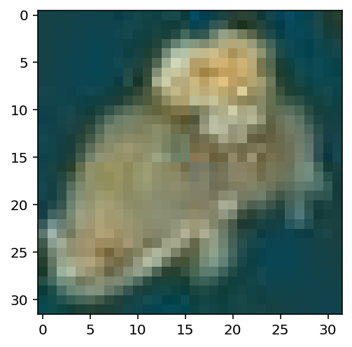

```
airplane
(3, 32, 32)
```

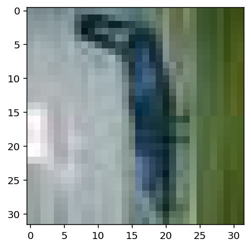

```
horse
(3, 32, 32)
```

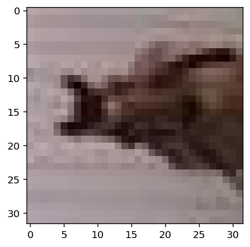

```
deer
(3, 32, 32)
```

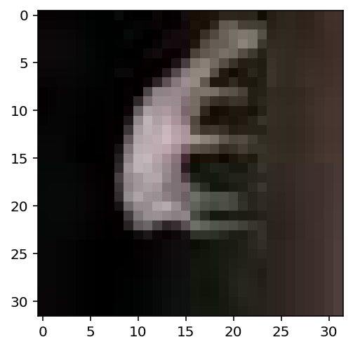

```python
# Explore data
show5(trainloader)
```

```
Clipping input data to the valid range for imshow with RGB data ([0..1] for floats or [0..255] for integers).
```

```
dog
(3, 224, 224)
```

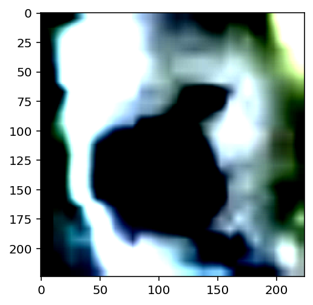

```
Clipping input data to the valid range for imshow with RGB data ([0..1] for floats or [0..255] for integers).
```

```
frog
(3, 224, 224)
```

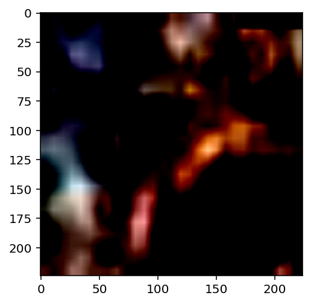

```
Clipping input data to the valid range for imshow with RGB data ([0..1] for floats or [0..255] for integers).
```

```
horse
(3, 224, 224)
```

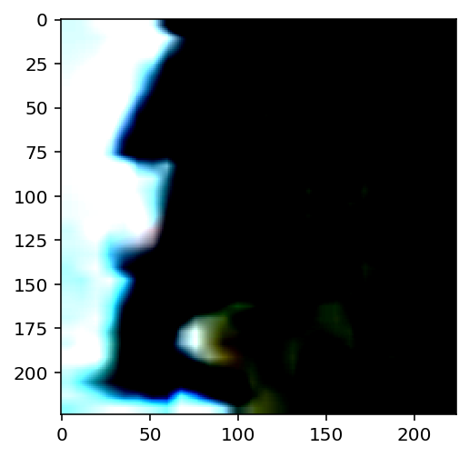

```
Clipping input data to the valid range for imshow with RGB data ([0..1] for floats or [0..255] for integers).
```

```
ship
(3, 224, 224)
```

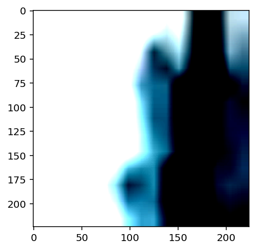

```
Clipping input data to the valid range for imshow with RGB data ([0..1] for floats or [0..255] for integers).
```

```
deer
(3, 224, 224)
```

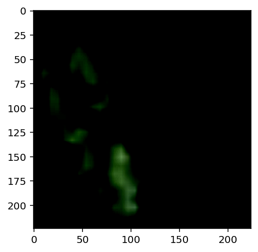

```python
show5(trainloader_transforms)
```

```python
def show_images_batch(d1):
    for images, labels in d1:
        fig, ax= plt.subplots(figsize=(16,8))
        ax.set_xticks([])
        ax.set_yticks([])
        ax.imshow(make_grid(images, nrow=16).permute(1,2,0))
        break # to stop loop otherwise 4500 images in batch size of 128 will print and is computationally expensive
```

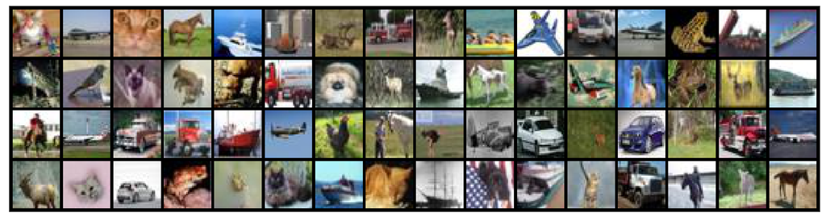

```python
show_images_batch(trainloader)
```

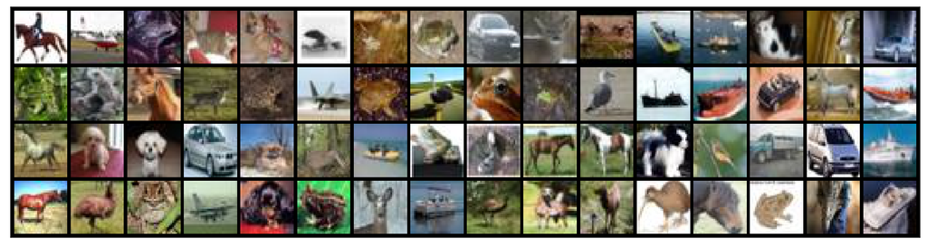

```python
show_images_batch(valloader)
```

```
Clipping input data to the valid range for imshow with RGB data ([0..1] for floats or [0..255] for integers).
```

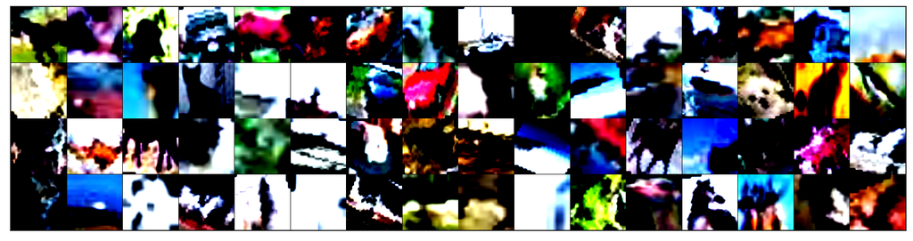

```python
show_images_batch(trainloader_transforms)
```

```
Clipping input data to the valid range for imshow with RGB data ([0..1] for floats or [0..255] for integers).
```

[figure not shown]

```python
show_images_batch(valloader_transforms)
```

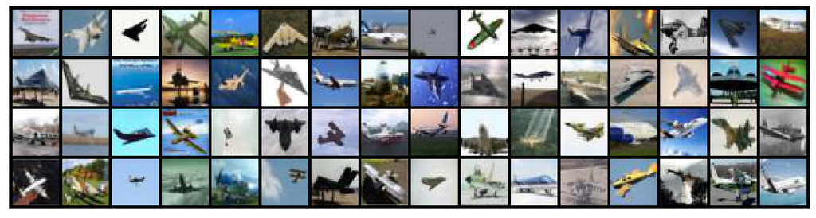

```python
show_images_batch(testloader)
```

```python
images,labels = next(iter(trainloader))
images.shape
```

```
torch.Size([64, 3, 32, 32])
```

### As you can see the every class has 5000 images in the train set, and 1000 image samples in the test set. And every image is of the size 32 X 32 with 3 channels(RGB).

## Build your Neural Network

Using the layers in `torch.nn` (which has been imported as `nn`) and the `torch.nn.functional` module (imported as `F`), construct a neural network based on the parameters of the dataset. Feel free to construct a model of any architecture – feedforward, convolutional, or even something more advanced!

Specify a loss function and an optimizer, and instantiate the model.

If you use a less common loss function, please note why you chose that loss function in a comment.

**I carried out expreiments with LogSoftmax as output layer with NLLLloss with VGGnet16, densenet121 both pretrained with layers frozen as well as training the whole model with the pretrained weights but out of all those permutation combinations i could not get an accuracy more then 56% on valset. There for i removed Logsoftmax and replaced NLLLoss with cross entropy loss and a simple CNN model gave an accuracy of 75%**

Here is a link for my wandb report of the experiments carried out: [here](https://wandb.ai/rohit18115/intro%20to%20machine%20learning%20nanodegree%20project%202/reports/Untitled-Report--VmlldzoxNzE0NzM5?accessToken=nh6jgo71w7srfsj9dgw1ur6jf3n74irmmlan0i0bwcgitm03hznpbsks4ziaxcc6)

```python
# Use GPU if it's available
device = torch.device("cuda" if torch.cuda.is_available() else "cpu")
print(device)

## YOUR CODE HERE ##
class Cifar10Model(nn.Module):
    def __init__(self):
        super().__init__()
        self.network = nn.Sequential(
            nn.Conv2d(3, 32, kernel_size=3, padding=1),
            nn.ReLU(),
            nn.Conv2d(32, 64, kernel_size=3, stride=1, padding=1),
            nn.ReLU(),
            nn.MaxPool2d(2, 2), # output: 64 x 16 x 16

            nn.Conv2d(64, 128, kernel_size=3, stride=1, padding=1),
            nn.ReLU(),
            nn.Conv2d(128, 128, kernel_size=3, stride=1, padding=1),
            nn.ReLU(),
            nn.MaxPool2d(2, 2), # output: 128 x 8 x 8

            nn.Conv2d(128, 128, kernel_size=3, stride=1, padding=1),
            nn.ReLU(),
#             nn.Conv2d(64, 64, kernel_size=3, stride=1, padding=1),
#             nn.ReLU(),
            nn.MaxPool2d(2, 2), # output: 128 x 4 x 4

            nn.Flatten(),
            nn.Linear(2048, 1024),
            nn.ReLU(),
            nn.Dropout(0.1),
            nn.Linear(1024, 512),
            nn.ReLU(),
            nn.Dropout(0.1),
            nn.Linear(512, 10))

    def forward(self, xb):
        return self.network(xb)
model = Cifar10Model()

# Freeze parameters so we don't backprop through them

# for param in model.parameters():
#     param.requires_grad = False

# model.classifier = nn.Sequential(nn.Linear(25088, 2048),
#                                  nn.ReLU(),
#                                  nn.Linear(2048, 256),
#                                  nn.ReLU(),
#                                  nn.Linear(256, 10),
#                                  nn.LogSoftmax(dim=1))


criterion = nn.CrossEntropyLoss()

# Only train the classifier parameters, feature parameters are frozen
optimizer = optim.Adam(model.parameters(), lr=0.001)

conf = {
    'model_name': 'cnn',
    'group': 'scratch',
    # 'classifier_layers_sizes':[25088,2048],
    'num_classes':10,
    'loss': criterion,
    'input_dim': (3,32,32),
    'dropout': 0.1,
    'hidden_layer_activation':nn.ReLU(),
    'batch_size':64,
    'lr':0.001,
    'optimizer': optimizer

}

wandb.init(project = 'intro to machine learning nanodegree project 2', group = 'scratch', config = conf)

model.to(device);
model
```

```
cuda
```

Run history:

| train_accuracy | ▁▄▅▅▆▆▇▇▇████ |
| --- | --- |
| train_loss | █▆▄▄▃▃▂▂▂▁▁▁▁ |
| val_accuracy | ▁▅▇▇▇████████ |
| val_loss | █▄▂▁▂▁▁▂▃▄▅▆▇ |

Run summary:

| train_accuracy | 0.94884 |
| --- | --- |
| train_loss | 0.14872 |
| val_accuracy | 0.72903 |
| val_loss | 1.43695 |

[output not shown]

```
Cifar10Model(
  (network): Sequential(
    (0): Conv2d(3, 32, kernel_size=(3, 3), stride=(1, 1), padding=(1, 1))
    (1): ReLU()
    (2): Conv2d(32, 64, kernel_size=(3, 3), stride=(1, 1), padding=(1, 1))
    (3): ReLU()
    (4): MaxPool2d(kernel_size=2, stride=2, padding=0, dilation=1, ceil_mode=False)
    (5): Conv2d(64, 128, kernel_size=(3, 3), stride=(1, 1), padding=(1, 1))
    (6): ReLU()
    (7): Conv2d(128, 128, kernel_size=(3, 3), stride=(1, 1), padding=(1, 1))
    (8): ReLU()
    (9): MaxPool2d(kernel_size=2, stride=2, padding=0, dilation=1, ceil_mode=False)
    (10): Conv2d(128, 128, kernel_size=(3, 3), stride=(1, 1), padding=(1, 1))
    (11): ReLU()
    (12): MaxPool2d(kernel_size=2, stride=2, padding=0, dilation=1, ceil_mode=False)
    (13): Flatten(start_dim=1, end_dim=-1)
    (14): Linear(in_features=2048, out_features=1024, bias=True)
    (15): ReLU()
    (16): Dropout(p=0.1, inplace=False)
    (17): Linear(in_features=1024, out_features=512, bias=True)
    (18): ReLU()
    (19): Dropout(p=0.1, inplace=False)
    (20): Linear(in_features=512, out_features=10, bias=True)
  )
)
```

```python
from tqdm.notebook import tqdm_notebook
import time
```

## Running your Neural Network

Use whatever method you like to train your neural network, and ensure you record the average loss at each epoch. Don't forget to use `torch.device()` and the `.to()` method for both your model and your data if you are using GPU!

If you want to print your loss during each epoch, you can use the `enumerate` function and print the loss after a set number of batches. 250 batches works well for most people!

```python
epochs = 40
steps = 0

train_losses, val_losses = [], []
for e in range(epochs):
    running_loss = 0
    train_accuracy = 0
    for images, labels in tqdm_notebook(trainloader):
        images = images.to(device)
        labels = labels.to(device)
#         print(images.shape, labels.shape)
        optimizer.zero_grad()

        log_ps = model(images)
        loss = criterion(log_ps, labels)
        loss.backward()
        optimizer.step()

        running_loss += loss.item()
        ps = torch.exp(log_ps)
        top_p, top_class = ps.topk(1, dim=1)
        equals = top_class == labels.view(*top_class.shape)
        train_accuracy += torch.mean(equals.type(torch.FloatTensor))


    else:
        val_loss = 0
        val_accuracy = 0

        # Turn off gradients for validation, saves memory and computations
        with torch.no_grad():
            model.eval()
            for images, labels in tqdm_notebook(valloader):
                images = images.to(device)
                labels = labels.to(device)
                log_ps = model(images)
                val_loss += criterion(log_ps, labels)

                ps = torch.exp(log_ps)
                top_p, top_class = ps.topk(1, dim=1)
                equals = top_class == labels.view(*top_class.shape)
                val_accuracy += torch.mean(equals.type(torch.FloatTensor))

        model.train()


        train_losses.append(running_loss/len(trainloader))
        val_losses.append(val_loss/len(valloader))
        wandb.log({"train_loss":train_losses[-1],
                   "val_loss":val_losses[-1],
                   "train_accuracy": train_accuracy/len(trainloader),
                   "val_accuracy": val_accuracy/len(valloader)})
        print("Epoch: {}/{}.. ".format(e+1, epochs),
              "Training Loss: {:.3f}.. ".format(train_losses[-1]),
              "Val Loss: {:.3f}.. ".format(val_losses[-1]),
              "train Accuracy: {:.3f}".format(train_accuracy/len(trainloader)),
              "Val Accuracy: {:.3f}".format(val_accuracy/len(valloader)))
```

```
Epoch: 1/40..  Training Loss: 1.623..  Val Loss: 1.342..  train Accuracy: 0.396 Val Accuracy: 0.514
```

```
Epoch: 2/40..  Training Loss: 1.135..  Val Loss: 1.160..  train Accuracy: 0.592 Val Accuracy: 0.598
```

```
Epoch: 3/40..  Training Loss: 0.940..  Val Loss: 0.986..  train Accuracy: 0.667 Val Accuracy: 0.660
```

```
Epoch: 4/40..  Training Loss: 0.803..  Val Loss: 0.835..  train Accuracy: 0.719 Val Accuracy: 0.708
```

```
Epoch: 5/40..  Training Loss: 0.693..  Val Loss: 0.809..  train Accuracy: 0.756 Val Accuracy: 0.729
```

```
Epoch: 6/40..  Training Loss: 0.600..  Val Loss: 0.806..  train Accuracy: 0.788 Val Accuracy: 0.734
```

```
Epoch: 7/40..  Training Loss: 0.521..  Val Loss: 0.771..  train Accuracy: 0.816 Val Accuracy: 0.749
```

```
Epoch: 8/40..  Training Loss: 0.441..  Val Loss: 0.813..  train Accuracy: 0.844 Val Accuracy: 0.738
```

```
Epoch: 9/40..  Training Loss: 0.373..  Val Loss: 0.841..  train Accuracy: 0.866 Val Accuracy: 0.751
```

```
Epoch: 10/40..  Training Loss: 0.318..  Val Loss: 0.943..  train Accuracy: 0.885 Val Accuracy: 0.749
```

```
Epoch: 11/40..  Training Loss: 0.273..  Val Loss: 0.966..  train Accuracy: 0.903 Val Accuracy: 0.741
```

[output not shown]

Plot the training loss (and validation loss/accuracy, if recorded).

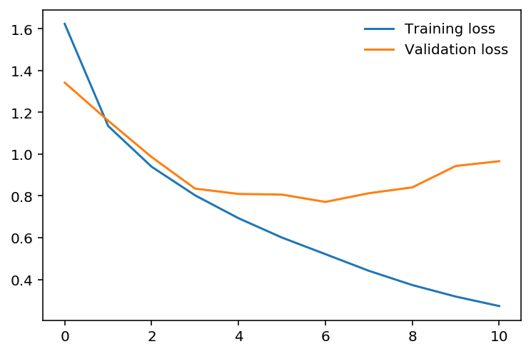

```python
plt.plot(train_losses, label='Training loss')
plt.plot(val_losses, label='Validation loss')
plt.legend(frameon=False)
```

## Testing your model

Using the previously created `DataLoader` for the test set, compute the percentage of correct predictions using the highest probability prediction.

If your accuracy is over 70%, great work! This is a hard task to exceed 70% on.

If your accuracy is under 45%, you'll need to make improvements. Go back and check your model architecture, loss function, and optimizer to make sure they're appropriate for an image classification task.

```python
def view_classify(img, ps, version="MNIST"):
    ''' Function for viewing an image and it's predicted classes.
    '''
    ps = ps.data.numpy().squeeze()

    fig, (ax1, ax2) = plt.subplots(figsize=(6,9), ncols=2)
    ax1.imshow(img.T)
    ax1.axis('off')
    ax2.barh(np.arange(10), ps)
    ax2.set_aspect(0.1)
    ax2.set_yticks(np.arange(10))
    if version == "MNIST":
        ax2.set_yticklabels(np.arange(10))
    elif version == "Fashion":
        ax2.set_yticklabels(['T-shirt/top',
                            'Trouser',
                            'Pullover',
                            'Dress',
                            'Coat',
                            'Sandal',
                            'Shirt',
                            'Sneaker',
                            'Bag',
                            'Ankle Boot'], size='small');
    if version == "CIFAR10":
        ax2.set_yticklabels(['airplane',
                             'automobile',
                             'bird',
                             'cat',
                             'deer',
                             'dog',
                             'frog',
                             'horse',
                             'ship',
                             'truck'], size='small')
    ax2.set_title('Class Probability')
    ax2.set_xlim(0, 1.0)

    plt.tight_layout()
```

```
torch.Size([3, 32, 32])
```

[figure not shown]

```python
# Test out your network!

model.eval()

dataiter = iter(testloader)
images, labels = dataiter.next()
img = images[50]
print(img.shape)
# Calculate the class probabilities (softmax) for img
with torch.no_grad():
    output = model.forward(images[50].resize_(1,3,32,32).to(device))

ps = output.cpu()

# Plot the image and probabilities
view_classify(img.view(3, 32, 32), ps, version='CIFAR10')
```

## Saving your model

Using `torch.save`, save your model for future loading.

```python
with wandb.init(project = 'intro to machine learning nanodegree project 2', group = 'scratch', config = conf) as run:
    config = wandb.config
    checkpoint = {'config': dict(config),
                  'state_dict': model.state_dict()}

    torch.save(checkpoint, 'cnn_scratch_crossentropy.pth')
    config = wandb.config
    model_artifact = wandb.Artifact(
                "cnn_scratch_crossentropy", type="model",
                description="cnn_scratch_crossentropy",
                metadata=dict(config))
    model_artifact.add_file("cnn_scratch_crossentropy.pth")

    wandb.save("cnn_scratch_crossentropy.pth")

    run.log_artifact(model_artifact)
```

Run history:

| train_accuracy | ▁▄▅▅▆▆▇▇▇██ |
| --- | --- |
| train_loss | █▅▄▄▃▃▂▂▂▁▁ |
| val_accuracy | ▁▃▅▇▇██████ |
| val_loss | █▆▄▂▁▁▁▂▂▃▃ |

Run summary:

| train_accuracy | 0.90323 |
| --- | --- |
| train_loss | 0.27254 |
| val_accuracy | 0.7413 |
| val_loss | 0.96594 |

[output not shown]

## Make a Recommendation

Based on your evaluation, what is your recommendation on whether to build or buy? Explain your reasoning below.